# Quem faz Iniciação Científica na USP?

- Mostrar o código
- Esconder o código
- Ver o código fonte

Estrutura de oportunidades e desigualdade no acesso à pesquisa de graduação (2010–2018)

Autores

Afiliações

Tales Mançano

Departamento de Ciência Política, Universidade de São Paulo

Victor Alcantara

Departamento de Sociologia, Universidade de São Paulo

Data de Publicação

30 de agosto de 2026

**RESUMO**

**Palavras-chave:** iniciação científica; desigualdade de oportunidades educacionais; estratificação horizontal; educação superior; gênero

**ABSTRACT**

**Keywords:** undergraduate research; inequality of educational opportunity; horizontal stratification; higher education; gender

Documento gerado por código: todas as tabelas e figuras são calculadas na compilação, a partir dos microdados. O pacote de replicação está em https://github.com/mancano-tales/Quem-faz-IC-USP, e é irmão do pacote do estudo anterior, https://github.com/mancano-tales/Quem-faz-IC-na-FFLCH.

## INTRODUÇÃO

Esta pesquisa investiga como o acesso à Iniciação Científica (IC) se distribui entre as unidades, as áreas do conhecimento e os cursos da Universidade de São Paulo, tomando as coortes que ingressaram na graduação entre 2010 e 2018.

Em trabalho anterior analisamos o perfil dos estudantes da Faculdade de Filosofia, Letras e Ciências Humanas que realizaram IC, e encontramos que o vínculo com o trabalho e a forma de sustento pretendida durante a graduação tinham peso maior sobre as chances de fazer pesquisa do que os marcadores tradicionalmente mobilizados pela literatura de desigualdades educacionais, como renda familiar e escolaridade dos responsáveis. Naquele texto, em sua versão apresentada em seminário, chegamos a levantar a existência de distinções entre as áreas do conhecimento, apoiados em Canaan e Nogueira (2015), para quem o capital cultural aparece positivamente correlacionado à chance de obter bolsa nas humanidades, relação que se inverteria nas demais áreas, possivelmente porque a carreira acadêmica não representa nelas a via mais prestigiosa de profissionalização. A discussão foi retirada da versão submetida por limite de espaço, e os dados de que dispúnhamos, restritos a uma unidade, não permitiriam investigá-la de todo modo.

Na seção seguinte situamos a IC na literatura sobre estratificação educacional, com atenção à vertente que trata da diferenciação horizontal no interior da educação superior. Em seguida descrevemos os dados, o recorte adotado e as escolhas metodológicas. Na terceira seção apresentamos a distribuição do acesso por área, unidade e curso, e a comparação entre o poder explicativo da estrutura institucional e o das características individuais. Na quarta seção aplicamos à universidade a especificação do estudo anterior e a estimamos separadamente em cada área. Encerramos com uma seção de robustez e as considerações finais.

## INICIAÇÃO CIENTÍFICA E ESTRUTURA DE OPORTUNIDADES

O modelo canônico da desigualdade de oportunidades educacionais trata a trajetória escolar como uma sequência de transições e mede o efeito da origem social sobre a probabilidade de completar cada uma (Mare, 1980). Sua regularidade mais citada é a de que esse efeito declina ao longo da sequência: quanto mais avançada a transição, menor o peso da origem (Breen e Jonsson, 2005:227). O achado do estudo anterior — origem fraca, trabalho forte, dentro de uma instituição seletiva — é consistente com essa regularidade.

Mas o declínio do efeito de origem ao longo das transições não significa que a desigualdade desapareça: ela se reorganiza. A literatura sobre estratificação horizontal formulou isso com precisão. Em sistemas expandidos, a desigualdade opera menos por *quanto* ensino as pessoas recebem e mais por *qual* ensino recebem — instituição, área, curso (Gerber e Cheung, 2008:300). No Brasil, Carvalhaes e Ribeiro (2019) mostraram que a estratificação horizontal do ensino superior opera por classe, gênero e raça, e que a expansão do acesso não a dissolveu; a revisão de Ribeiro e Carvalhaes (2020) situa esse resultado num conjunto amplo de evidências sobre a persistência dos efeitos de origem.

A Iniciação Científica pertence a esse registro, mas num nível ainda mais fino. Não é uma transição que se completa ou não, nem a escolha de um curso: é um recurso opcional e disputado que distingue trajetórias *dentro* de um mesmo diploma, e que funciona como credencial de entrada na pós-graduação (Canaan e Nogueira, 2015:63). Perguntar quem faz IC é perguntar por diferenciação qualitativa no interior da educação superior pública.

### A medida da estrutura de oportunidades

A literatura sobre estratificação horizontal costuma operacionalizar a distribuição desigual entre cursos e instituições como resultado de seleção: estudantes de origens sociais distintas se alocam de maneira desigual entre as opções disponíveis, e é essa alocação que produz destinos desiguais. A oferta comparece nessa formulação sobretudo como o contexto em que a seleção ocorre.

Neste artigo procuramos tratá-la como quantidade. Estimamos quanto da variação individual na realização de IC é explicado apenas por saber em que unidade o estudante ingressou, e comparamos esse valor com o poder explicativo do conjunto de suas características socioeconômicas. A pergunta usual, sobre quem consegue o recurso, passa a ser acompanhada de outra, sobre onde o recurso existe em maior quantidade.

A distinção tem consequência para a discussão de políticas. Caso a oferta responda pela maior parte da variação, iniciativas de equidade que atuem apenas sobre o perfil dos beneficiários, como critérios socioeconômicos na seleção de bolsistas, estariam operando sobre a menor das duas fontes envolvidas.

### O tempo como mecanismo

A conclusão do estudo anterior dialoga com Comin e Barbosa (2011:75), para quem a expansão do sistema trouxe à educação superior brasileira um público que não é feito de estudantes que trabalham, mas de trabalhadores que estudam.

Vale precisar o que essa tese afirma e o que não afirma. Ela não nega o efeito da origem: a necessidade de trabalhar é, ela própria, produzida pela origem. O que sustenta é que, *condicionalmente ao ingresso numa instituição seletiva*, o canal pelo qual a origem continua operando muda de natureza — de recursos e disposições para tempo disponível. É uma hipótese sobre o mecanismo, não sobre a magnitude total da desigualdade.

Uma hipótese assim só pode ser avaliada onde ela poderia falhar. Uma unidade com alta proporção de estudantes noturnos e trabalhadores é o lugar mais favorável possível para encontrá-la. Estendê-la a áreas de perfil oposto não é exercício de generalização, mas de teste.

## DADOS E MÉTODO

**código**

```r
data.frame(
  Medida = c("Ingressantes na USP (coortes 2010–2018)", "Unidades",
             "Áreas do conhecimento", "Cursos de ingresso",
             "Estudantes que realizaram IC", "Proporção que realizou IC",
             "A mesma proporção, na FFLCH"),
  Valor = c(num(nrow(usp)), num(dplyr::n_distinct(usp$unidade)),
            num(dplyr::n_distinct(usp$area)), num(dplyr::n_distinct(usp$curso)),
            num(sum(usp$IC)), pct(mean(usp$IC)), pct(mean(fflch$IC)))
) |> knitr::kable(align = "lr")
```

Tabela 1: O painel analisado

| Medida | Valor |
| --- | --- |
| Ingressantes na USP (coortes 2010–2018) | 105.803 |
| Unidades | 47 |
| Áreas do conhecimento | 9 |
| Cursos de ingresso | 122 |
| Estudantes que realizaram IC | 14.658 |
| Proporção que realizou IC | 13,9% |
| A mesma proporção, na FFLCH | 11,3% |

Fonte: elaboração própria a partir de dados do SIC-USP.

### Duas janelas de coorte

Os dados de IC terminam em 2022. Quem ingressou em 2021 ou 2022 ainda não teve tempo de iniciar uma pesquisa dentro do período observado, e aparece como se não tivesse feito: a coorte de 2022 marca 1,8% contra 16,1% da de 2018. São coortes censuradas à direita.

As descritivas usam por isso as coortes de **2010 a 2018**, que tiveram ao menos quatro anos de observação. Os modelos usam **2010 a 2022**, a amostra do estudo anterior, para que os coeficientes sejam diretamente comparáveis; o modelo controla o ano de ingresso, e a última seção mostra o efeito de estimá-lo nas duas janelas.

### Efeitos marginais médios

Optamos por comparar efeitos marginais médios em lugar dos coeficientes. Coeficientes logísticos de variáveis medidas em escalas distintas, como salários mínimos, anos de idade e categorias de vínculo com o trabalho, não são comparáveis entre si. O efeito marginal médio exprime todos em pontos percentuais na probabilidade de realizar IC, que é a unidade em que a pergunta sobre qual fator pesa mais admite resposta. Os intervalos de confiança vêm do método delta aplicado à matriz de covariância do modelo.

## QUANTA IC EXISTE, E ONDE

A primeira resposta é que a FFLCH não é a USP.

**código**

```r
tab_areas <- usp |>
  dplyr::group_by(area) |>
  dplyr::summarise(
    N = dplyr::n(), fez_ic = mean(IC),
    ppi = mean(raca == "PPI", na.rm = TRUE),
    noturno = mean(periodo == "noturno", na.rm = TRUE),
    trabalha = mean(trabalho != "Não", na.rm = TRUE),
    renda_pc = stats::median(sfmpct, na.rm = TRUE), .groups = "drop") |>
  dplyr::arrange(dplyr::desc(fez_ic))

tab_areas |>
  dplyr::transmute(`Área` = area, N = num(N), `% fez IC` = pct(fez_ic),
                   `% PPI` = pct(ppi), `% noturno` = pct(noturno),
                   `% trabalha` = pct(trabalha),
                   `Renda p/c (SM)` = format(round(renda_pc, 2), decimal.mark = ",")) |>
  knitr::kable(align = "lrrrrrr")
```

Tabela 2: Acesso à IC e composição social, por área do conhecimento (coortes 2010–2018)

| Área | N | % fez IC | % PPI | % noturno | % trabalha | Renda p/c (SM) |
| --- | --- | --- | --- | --- | --- | --- |
| Ciências da Saúde | 13.871 | 27,5% | 15,6% | 19,8% | 13,8% | 1,50 |
| Ciências Agrárias | 7.142 | 22,8% | 10,9% | 21,0% | 13,2% | 1,50 |
| Ciências Biológicas | 1.489 | 21,6% | 14,7% | 38,6% | 17,2% | 2,00 |
| Engenharias | 15.148 | 14,4% | 12,8% | 6,5% | 8,8% | 2,12 |
| Ciências Humanas | 17.954 | 11,7% | 22,5% | 51,2% | 46,1% | 1,75 |
| Ciências Exatas e da Terra | 14.231 | 10,5% | 19,3% | 37,2% | 31,2% | 1,50 |
| Ciências Sociais Aplicadas | 16.344 | 9,1% | 12,6% | 46,3% | 20,0% | 3,00 |
| Multidisciplinar | 15.770 | 8,5% | 22,6% | 37,8% | 30,2% | 1,20 |
| Linguística, Letras e Artes | 3.854 | 7,6% | 18,7% | 42,3% | 35,4% | 2,00 |

Fonte: elaboração própria a partir de dados do SIC-USP.

Ciências da Saúde forma estudantes com IC em proporção mais de três vezes maior que Linguística, Letras e Artes. A FFLCH, com 11,3%, fica próxima da média de sua área e abaixo da média da universidade (13,9%).

### A dispersão dentro das áreas e dos cursos

**código**

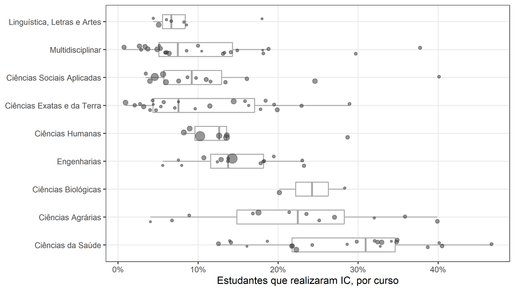

Figura 1: Proporção que realizou IC em cada curso, agrupada por área (cursos com 200 ingressantes ou mais)

```r
MIN_CURSO <- 200

cursos <- usp |>
  dplyr::group_by(area, unidade, curso) |>
  dplyr::summarise(n = dplyr::n(), fez_ic = mean(IC), .groups = "drop") |>
  dplyr::filter(n >= MIN_CURSO) |>
  dplyr::arrange(dplyr::desc(fez_ic)) |>
  dplyr::group_by(curso) |>
  dplyr::mutate(rotulo = if (dplyr::n() > 1)
                  paste0(curso, " — ", campus_unidade(unidade)) else curso) |>
  dplyr::ungroup()

cursos |>
  ggplot2::ggplot(ggplot2::aes(x = area, y = fez_ic)) +
  ggplot2::geom_boxplot(outlier.shape = NA, colour = "grey65", width = 0.5) +
  ggplot2::geom_jitter(ggplot2::aes(size = n), width = 0.18, alpha = 0.55,
                       colour = "grey25") +
  ggplot2::scale_y_continuous(labels = scales::percent) +
  ggplot2::scale_size_continuous(range = c(0.8, 5), guide = "none") +
  ggplot2::coord_flip() +
  ggplot2::labs(x = NULL, y = "Estudantes que realizaram IC, por curso") +
  TEMA
```

Fonte: elaboração própria a partir de dados do SIC-USP.

**código**

```r
rbind(utils::head(cursos, 8), utils::tail(cursos, 8)) |>
  dplyr::transmute(Curso = rotulo, `Área` = abreviar_area(area),
                   N = num(n), `% fez IC` = pct(fez_ic)) |>
  knitr::kable(align = "llrr")
```

Tabela 3: Os oito cursos com maior e menor proporção de estudantes que realizaram IC

| Curso | Área | N | % fez IC |
| --- | --- | --- | --- |
| Odontologia — Bauru | C. da Saúde | 450 | 46,7% |
| Enfermagem — São Paulo | C. da Saúde | 741 | 40,5% |
| Fonoaudiologia — Bauru | C. da Saúde | 314 | 40,1% |
| Arquitetura e Urbanismo — São Carlos | C. Sociais Aplicadas | 384 | 40,1% |
| Medicina Veterinária — São Paulo | C. Agrárias | 767 | 39,9% |
| Bacharelado e Licenciatura em Enfermagem | C. da Saúde | 447 | 38,7% |
| Ciências Biológicas — Ribeirão Preto | Multidisciplinar | 477 | 37,7% |
| Medicina Veterinária — Pirassununga | C. Agrárias | 580 | 35,9% |
| Bacharelado em Lazer e Turismo | Multidisciplinar | 1.129 | 3,4% |
| Física Licenciatura | C. Exatas e da Terra | 1.187 | 3,2% |
| Licenciatura em Ciências Exatas | Multidisciplinar | 414 | 2,9% |
| Licenciatura em Geociências e Educação Ambiental | C. Exatas e da Terra | 434 | 2,8% |
| Marketing | Multidisciplinar | 1.130 | 2,7% |
| Bacharelado em Matemática Aplicada e Computacional | C. Exatas e da Terra | 623 | 2,1% |
| Matemática Licenciatura | C. Exatas e da Terra | 1.483 | 0,9% |
| Licenciatura em Ciências | Multidisciplinar | 1.064 | 0,8% |

Fonte: elaboração própria a partir de dados do SIC-USP.

Um padrão organiza o fundo do ranking. Estudantes vinculados apenas à licenciatura realizam IC em proporção pouco acima da metade da dos vinculados apenas ao bacharelado.

**código**

```r
# Os campos de situação marcam a ausência de vínculo com a frase
# "Não cursa/cursou ...", e não com um valor faltante.
tem_vinculo <- function(x, ausencia) !is.na(x) & x != ausencia

usp |>
  dplyr::mutate(
    bac = tem_vinculo(situ_bacharel, "Não cursa/cursou bacharelado"),
    lic = tem_vinculo(situ_licenciatura, "Não cursa/cursou licenciatura"),
    tipo = dplyr::case_when(
      bac & lic ~ "Bacharelado e licenciatura",
      bac & !lic ~ "Somente bacharelado",
      !bac & lic ~ "Somente licenciatura",
      TRUE ~ "Sem vínculo registrado")) |>
  dplyr::group_by(tipo) |>
  dplyr::summarise(N = dplyr::n(), fez_ic = mean(IC), .groups = "drop") |>
  dplyr::arrange(dplyr::desc(fez_ic)) |>
  dplyr::transmute(`Vínculo` = tipo, N = num(N), `% fez IC` = pct(fez_ic)) |>
  knitr::kable(align = "lrr")
```

Tabela 4: Acesso à IC segundo o vínculo do estudante com bacharelado e licenciatura

| Vínculo | N | % fez IC |
| --- | --- | --- |
| Bacharelado e licenciatura | 12.592 | 17,2% |
| Sem vínculo registrado | 8.956 | 15,8% |
| Somente bacharelado | 76.156 | 13,7% |
| Somente licenciatura | 8.099 | 7,5% |

Fonte: elaboração própria a partir de dados do SIC-USP.

A leitura mais provável não é de desigualdade, mas de desenho: a licenciatura forma professores, e a IC não faz parte do que se espera dessa trajetória. Mas o efeito prático é que uma porta para a pós-graduação está estatisticamente mais fechada para quem entrou pela formação docente — e essa é, na USP, a modalidade com maior concentração de estudantes noturnos e trabalhadores.

### Coorte a coorte

As médias do período escondem trajetórias. Uma unidade pode ter média alta porque começou alta e caiu, ou porque começou baixa e subiu — e a distinção importa para qualquer leitura sobre expansão da política.

**código**

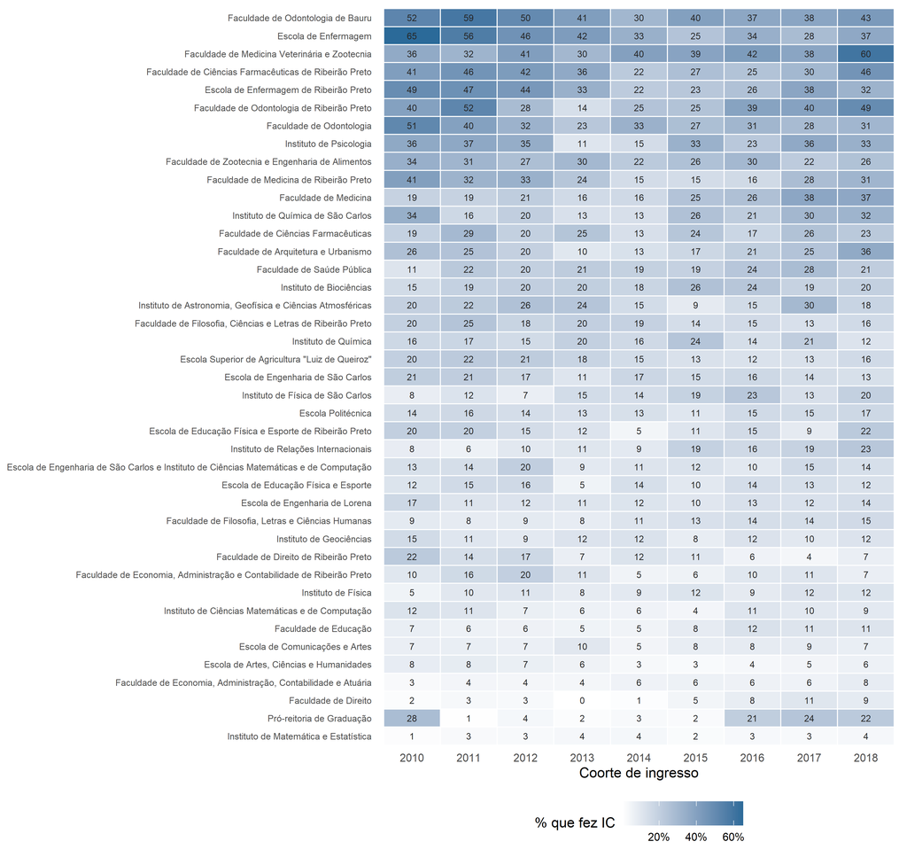

Figura 2: Proporção de estudantes que realizaram IC, por unidade e coorte de ingresso (unidades com 500 ingressantes ou mais no período). Valores em porcentagem.

```r
por_unidade <- usp |>
  dplyr::group_by(unidade, ano) |>
  dplyr::summarise(n = dplyr::n(), fez = sum(IC), prop = mean(IC), .groups = "drop")

grandes <- por_unidade |>
  dplyr::group_by(unidade) |>
  dplyr::summarise(total = sum(n), media = sum(fez) / sum(n), .groups = "drop") |>
  dplyr::filter(total >= MIN_INGRESSANTES)

por_unidade <- dplyr::semi_join(por_unidade, grandes, by = "unidade") |>
  dplyr::left_join(grandes, by = "unidade")

por_unidade |>
  ggplot2::ggplot(ggplot2::aes(x = factor(ano),
                               y = stats::reorder(unidade, media), fill = prop)) +
  ggplot2::geom_tile(colour = "white", linewidth = 0.4) +
  ggplot2::geom_text(ggplot2::aes(label = sprintf("%.0f", 100 * prop)),
                     size = 2.3, colour = "grey15") +
  ggplot2::scale_fill_gradient(low = "white", high = "#2b6a99",
                               labels = scales::percent, name = "% que fez IC") +
  ggplot2::labs(x = "Coorte de ingresso", y = NULL) +
  ggplot2::theme_minimal(base_size = 10) +
  ggplot2::theme(panel.grid = ggplot2::element_blank(),
                 legend.position = "bottom",
                 axis.text.y = ggplot2::element_text(size = 6.5))
```

Fonte: elaboração própria a partir de dados do SIC-USP. As tabelas completas por unidade e por curso, ano a ano, estão no pacote de replicação.

Antes de ler a figura, um cuidado. A censura das coortes recentes tem um espelho: quem ingressou em 2010 teve doze anos de observação; quem ingressou em 2018, quatro. Se a IC fosse iniciada tardiamente na graduação, as coortes antigas apareceriam infladas e qualquer queda seria artefato. Recalculamos por isso o indicador contando apenas as ICs iniciadas em até cinco anos após o ingresso — janela igual para todas as coortes. A série não se move: a maior diferença entre os dois indicadores é de 0.23 ponto percentual. Praticamente toda IC começa nos primeiros anos do curso, e as trajetórias abaixo são reais.

**código**

```r
trajetoria <- por_unidade |>
  dplyr::filter(ano %in% c(2010, 2018)) |>
  dplyr::select(unidade, ano, prop) |>
  tidyr::pivot_wider(names_from = ano, values_from = prop,
                     names_prefix = "a") |>
  dplyr::mutate(delta = a2018 - a2010) |>
  dplyr::arrange(dplyr::desc(delta))

rbind(utils::head(trajetoria, 5), utils::tail(trajetoria, 5)) |>
  dplyr::transmute(Unidade = unidade, `2010` = pct(a2010), `2018` = pct(a2018),
                   `Variação` = sprintf("%+.1f p.p.", 100 * delta)) |>
  knitr::kable(align = "lrrr")
```

Tabela 5: As maiores altas e quedas no acesso à IC entre as coortes de 2010 e 2018

| Unidade | 2010 | 2018 | Variação |
| --- | --- | --- | --- |
| Faculdade de Medicina Veterinária e Zootecnia | 35,8% | 60,0% | +24.2 p.p. |
| Faculdade de Medicina | 18,9% | 37,0% | +18.1 p.p. |
| Instituto de Relações Internacionais | 7,9% | 23,4% | +15.5 p.p. |
| Instituto de Física de São Carlos | 7,6% | 19,7% | +12.1 p.p. |
| Faculdade de Arquitetura e Urbanismo | 26,3% | 35,9% | +9.6 p.p. |
| Faculdade de Medicina de Ribeirão Preto | 40,8% | 31,0% | -9.8 p.p. |
| Faculdade de Direito de Ribeirão Preto | 22,2% | 7,1% | -15.1 p.p. |
| Escola de Enfermagem de Ribeirão Preto | 48,9% | 32,1% | -16.8 p.p. |
| Faculdade de Odontologia | 51,1% | 30,7% | -20.5 p.p. |
| Escola de Enfermagem | 65,0% | 36,7% | -28.3 p.p. |

Fonte: elaboração própria a partir de dados do SIC-USP.

Trata-se de variação que uma leitura agregada não recupera, e que converge com o argumento desenvolvido na seção anterior. A oferta de IC responde a decisões institucionais, tomadas no âmbito das unidades e de seus programas de bolsas, cujo resultado agregado não se confunde com a soma das escolhas dos estudantes.

### A estrutura institucional contra as características individuais

Quanto pesa o lugar em que o estudante ingressa, comparado ao que ele traz consigo? A comparação exige dois cuidados. O primeiro é a amostra: o modelo individual descarta quem tem resposta faltante no questionário — cerca de 30% dos casos, que não faltam ao acaso —, de modo que os blocos precisam ser estimados sobre o mesmo conjunto. O segundo é o número de parâmetros: a unidade entra como 47 categorias contra 15 termos individuais, e o pseudo-R² de McFadden não penaliza parâmetros. Reportamos por isso o McFadden ajustado e o BIC, que penaliza com severidade.

**código**

```r
amostra_comum <- usp |>
  dplyr::select(dplyr::all_of(VARIAVEIS), unidade, area) |>
  stats::na.exclude()

nulo <- stats::glm(IC ~ 1, data = amostra_comum, family = stats::binomial)
mcf     <- function(m) 1 - as.numeric(stats::logLik(m) / stats::logLik(nulo))
mcf_adj <- function(m) 1 - (as.numeric(stats::logLik(m)) - length(stats::coef(m))) /
  as.numeric(stats::logLik(nulo))

blocos <- list(
  "Área do conhecimento (9 categorias)" =
    stats::glm(IC ~ area, data = amostra_comum, family = stats::binomial),
  "Unidade de ingresso (48 categorias)" =
    stats::glm(IC ~ unidade, data = amostra_comum, family = stats::binomial),
  "Características do estudante (o modelo do estudo anterior)" =
    ajustar(amostra_comum, FORMULA_BASE))

data.frame(
  `O que o modelo conhece` = names(blocos),
  `Parâmetros` = vapply(blocos, function(m) length(stats::coef(m)), numeric(1)),
  `Pseudo-R²` = sprintf("%.4f", vapply(blocos, mcf, numeric(1))),
  `Ajustado` = sprintf("%.4f", vapply(blocos, mcf_adj, numeric(1))),
  `BIC` = num(round(vapply(blocos, stats::BIC, numeric(1)))),
  check.names = FALSE, row.names = NULL) |>
  knitr::kable(align = "lrrrr")
```

Tabela 6: Poder explicativo de cada bloco de informação, isoladamente, na mesma amostra

| O que o modelo conhece | Parâmetros | Pseudo-R² | Ajustado | BIC |
| --- | --- | --- | --- | --- |
| Área do conhecimento (9 categorias) | 9 | 0.0435 | 0.0432 | 57.366 |
| Unidade de ingresso (48 categorias) | 47 | 0.0793 | 0.0777 | 55.654 |
| Características do estudante (o modelo do estudo anterior) | 16 | 0.0567 | 0.0561 | 56.659 |

Fonte: elaboração própria a partir de dados do SIC-USP. N = 73.889.

Esse resultado chama atenção para a dimensão institucional do acesso a oportunidades de pesquisa na graduação. A distribuição desigual da IC entre as unidades não decorre somente do perfil dos estudantes que cada uma recebe, mas de diferenças na oferta que antecedem esse perfil. Uma leitura que se concentre nos atributos dos indivíduos, como a que fizemos no estudo anterior, estará descrevendo a menor das duas fontes de variação envolvidas.

## A ESPECIFICAÇÃO ANTERIOR APLICADA À USP

Mantemos a especificação do estudo anterior intacta. Se mudássemos o modelo junto com a amostra, não saberíamos qual das duas mudanças explica a diferença. A única adição é o efeito fixo de área, sem o qual o coeficiente de qualquer variável confundiria o efeito individual com o fato de certas áreas ofertarem mais IC.

**código**

```r
md_fflch <- amostra_modelo(fflch_mod)
md_usp   <- amostra_modelo(mod, com_area = TRUE)

m_fflch <- ajustar(md_fflch, FORMULA_BASE)
m_usp   <- ajustar(md_usp, FORMULA_AREA)

a_fflch <- ame(m_fflch, md_fflch)
a_usp   <- ame(m_usp, md_usp)

juntar <- function(a, nome) {
  a |>
    dplyr::filter(!grepl("^area", variavel)) |>
    dplyr::transmute(termo = paste0(variavel, ": ", nivel),
                     v = sprintf("%+.2f %s", 100 * ame, ic(inf, sup))) |>
    stats::setNames(c("termo", nome))
}

dplyr::full_join(juntar(a_fflch, "FFLCH"), juntar(a_usp, "USP"), by = "termo") |>
  dplyr::rename(Efeito = termo) |>
  knitr::kable(align = "lrr")
```

Tabela 7: Efeitos marginais médios sobre a probabilidade de realizar IC, em pontos percentuais, com intervalos de confiança de 95%

| Efeito | FFLCH | USP |
| --- | --- | --- |
| ano: +1 desvio-padrão | -1.73 [-2.15; -1.31] | -2.80 [-2.96; -2.64] |
| idade: +1 desvio-padrão | -3.46 [-4.10; -2.81] | -2.87 [-3.18; -2.56] |
| sexo: M (vs F) | -0.12 [-1.04; +0.80] | -3.13 [-3.52; -2.74] |
| raca: PPI (vs Brancos) | -1.18 [-2.25; -0.11] | -1.73 [-2.22; -1.25] |
| educ_resp: EM completo (vs EF incompleto) | +0.39 [-0.86; +1.63] | -0.28 [-0.86; +0.30] |
| educ_resp: ES completo (vs EF incompleto) | +0.59 [-0.69; +1.88] | -0.40 [-0.99; +0.19] |
| sfmpct: +1 desvio-padrão | -1.20 [-1.81; -0.59] | -0.77 [-1.01; -0.53] |
| trabalho: Sim, em tempo integral (vs Não) | -2.35 [-3.88; -0.81] | -3.73 [-4.59; -2.86] |
| trabalho: Sim, em tempo parcial (vs Não) | +0.25 [-0.96; +1.47] | -1.25 [-1.85; -0.65] |
| sustento: Por conta própria (vs Suporte da família) | -2.89 [-4.32; -1.47] | -3.28 [-4.07; -2.50] |
| sustento: Com bolsa e apoio da família (vs Suporte da família) | +2.26 [+0.85; +3.67] | +1.75 [+1.22; +2.29] |
| sustento: Com trabalho e apoio da família (vs Suporte da família) | -2.64 [-4.00; -1.28] | -2.23 [-2.94; -1.51] |
| sustento: Outros (vs Suporte da família) | +1.54 [-2.98; +6.06] | -0.36 [-2.19; +1.47] |
| periodo: noturno (vs diurno) | -2.72 [-3.68; -1.76] | -3.06 [-3.49; -2.64] |
| class_carreira: +1 desvio-padrão | -1.21 [-1.67; -0.75] | -1.89 [-2.12; -1.67] |

Fonte: elaboração própria a partir de dados do SIC-USP. FFLCH: N = 16.974; USP: N = 111.330.

A comparação sugere três leituras.

A primeira é que o peso do trabalho se mantém na universidade e é maior do que o observado na unidade. Trabalhar em tempo integral ao prestar o vestibular reduz a probabilidade de realizar IC em 3.73 pontos percentuais na USP, contra 2.35 na FFLCH, e os efeitos de sustentar-se por conta própria e de estudar no período noturno acompanham essa direção, também com magnitude maior. O achado do estudo anterior não parece ter sido produzido pelas particularidades da unidade analisada.

A segunda é que as características de origem seguem com efeitos pequenos, e a escolaridade dos responsáveis não se distingue de zero. Renda per capita e raça mantêm coeficientes modestos. A escolaridade do responsável, que na FFLCH aparecia com sinal positivo, tem na USP intervalo de confiança que cruza o zero nos dois níveis, de modo que não há evidência de efeito em nenhuma direção.

A terceira diz respeito ao sexo, que na FFLCH não se distinguia de zero (-0.12 ponto percentual, com intervalo cruzando o zero) e na USP alcança -3.13 pontos. Como o modelo inclui efeitos fixos de área, o resultado não decorre de homens estarem concentrados em áreas com menor oferta de IC. Voltamos a ele adiante, com um controle mais exigente.

**código**

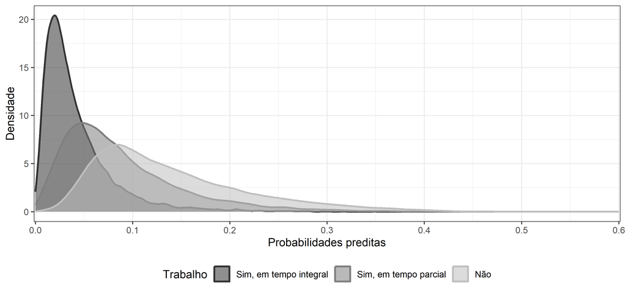

Figura 3: Densidade das probabilidades preditas de realizar IC, conforme o vínculo com o trabalho e a pretensão de sustento

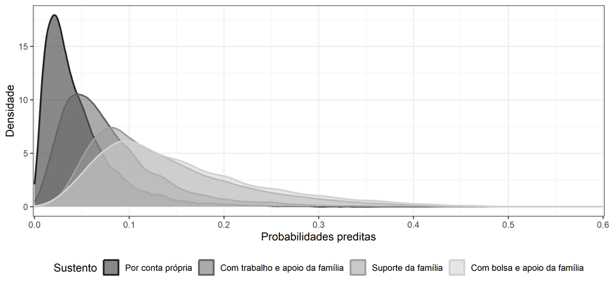

Figura 4: Densidade das probabilidades preditas de realizar IC, conforme o vínculo com o trabalho e a pretensão de sustento

```r
md_usp$p <- stats::predict(m_usp, md_usp, type = "response")

tema_dens <- ggplot2::theme_bw(base_size = 11) +
  ggplot2::theme(legend.position = "bottom")

cores_trab <- c("Sim, em tempo integral" = "grey20",
                "Sim, em tempo parcial" = "grey50", "Não" = "grey75")
cores_sust <- c("Por conta própria" = "grey15",
                "Com trabalho e apoio da família" = "grey40",
                "Suporte da família" = "grey62",
                "Com bolsa e apoio da família" = "grey82")

md_usp |>
  dplyr::mutate(trabalho = factor(trabalho, levels = names(cores_trab))) |>
  ggplot2::ggplot(ggplot2::aes(x = p, colour = trabalho, fill = trabalho)) +
  ggplot2::geom_density(linewidth = 0.9, alpha = 0.55) +
  ggplot2::scale_fill_manual(values = cores_trab) +
  ggplot2::scale_colour_manual(values = cores_trab) +
  ggplot2::scale_x_continuous(limits = c(0, 0.6), expand = c(0.001, 0.001)) +
  ggplot2::labs(x = "Probabilidades preditas", y = "Densidade",
                colour = "Trabalho", fill = "Trabalho") + tema_dens

md_usp |>
  dplyr::filter(sustento != "Outros") |>
  dplyr::mutate(sustento = factor(as.character(sustento), names(cores_sust))) |>
  ggplot2::ggplot(ggplot2::aes(x = p, colour = sustento, fill = sustento)) +
  ggplot2::geom_density(linewidth = 0.9, alpha = 0.55) +
  ggplot2::scale_fill_manual(values = cores_sust) +
  ggplot2::scale_colour_manual(values = cores_sust) +
  ggplot2::scale_x_continuous(limits = c(0, 0.6), expand = c(0.001, 0.001)) +
  ggplot2::labs(x = "Probabilidades preditas", y = "Densidade",
                colour = "Sustento", fill = "Sustento") + tema_dens
```

Fonte: elaboração própria a partir de dados do SIC-USP.

## O MESMO MODELO, ÁREA POR ÁREA

Confirmar o mecanismo em agregado não garante que ele opere em toda parte. Se o trabalho fosse o obstáculo dominante em Humanas e irrelevante em Saúde, o achado anterior descreveria um tipo de área, não a universidade.

**código**

```r
areas <- sort(unique(mod$area))

ajustes <- Filter(Negate(is.null), lapply(areas, function(a) {
  d <- amostra_modelo(dplyr::filter(mod, area == a))
  if (nrow(d) < 500) return(NULL)
  list(area = a, modelo = ajustar(d, FORMULA_BASE), dados = d)
}))

ames_area <- do.call(rbind, lapply(ajustes, function(x) {
  cbind(area = x$area, n = stats::nobs(x$modelo), ame(x$modelo, x$dados))
}))

DESTAQUES <- c(
  "trabalho|Sim, em tempo integral (vs Não)" = "Trab. integral",
  "sustento|Por conta própria (vs Suporte da família)" = "Sust. próprio",
  "periodo|noturno (vs diurno)" = "Noturno",
  "sexo|M (vs F)" = "Homem",
  "raca|PPI (vs Brancos)" = "PPI",
  "sfmpct|+1 desvio-padrão" = "Renda p/c",
  "educ_resp|ES completo (vs EF incompleto)" = "Pais c/ ES")

destaques <- ames_area |>
  dplyr::mutate(chave = paste(variavel, nivel, sep = "|")) |>
  dplyr::filter(chave %in% names(DESTAQUES)) |>
  dplyr::mutate(efeito = factor(unname(DESTAQUES[chave]),
                                levels = unname(DESTAQUES)))

destaques |>
  dplyr::mutate(pp = sprintf("%+.1f", 100 * ame)) |>
  dplyr::select(area, n, efeito, pp) |>
  tidyr::pivot_wider(names_from = efeito, values_from = pp) |>
  dplyr::select(`Área` = area, N = n, dplyr::all_of(unname(DESTAQUES))) |>
  dplyr::mutate(`Área` = abreviar_area(`Área`), N = num(N)) |>
  knitr::kable(align = "lrrrrrrrr")
```

Tabela 8: Efeitos marginais médios por área, em pontos percentuais

| Área | N | Trab. integral | Sust. próprio | Noturno | Homem | PPI | Renda p/c | Pais c/ ES |
| --- | --- | --- | --- | --- | --- | --- | --- | --- |
| C. da Saúde | 16.061 | -4.6 | -6.6 | -1.6 | -6.8 | -2.8 | -1.0 | -0.5 |
| C. Biológicas | 1.631 | -2.4 | -1.5 | -10.5 | -1.7 | -3.0 | -1.1 | -1.8 |
| C. Agrárias | 8.213 | -6.1 | -4.5 | +0.7 | -8.1 | -3.2 | -1.7 | -1.8 |
| Engenharias | 13.757 | -0.9 | -1.4 | -3.1 | -3.8 | -2.0 | -0.4 | -2.4 |
| C. Humanas | 19.430 | -2.6 | -3.0 | -3.4 | -0.1 | -1.2 | -1.2 | +0.6 |
| C. Exatas e da Terra | 14.256 | -3.8 | -3.2 | -4.7 | -2.5 | -1.7 | -0.4 | +1.7 |
| C. Sociais Aplicadas | 17.791 | -2.0 | -1.4 | -2.9 | -3.1 | -0.3 | -0.6 | -0.5 |
| Multidisciplinar | 16.061 | -4.1 | -1.8 | -2.2 | -0.6 | -1.6 | +0.1 | -0.6 |
| Letras e Artes | 4.130 | +0.2 | -2.8 | -3.4 | -0.6 | -0.1 | +0.0 | -1.9 |

Fonte: elaboração própria a partir de dados do SIC-USP. Estimativas pontuais; os intervalos de confiança estão na Figura 5.

**código**

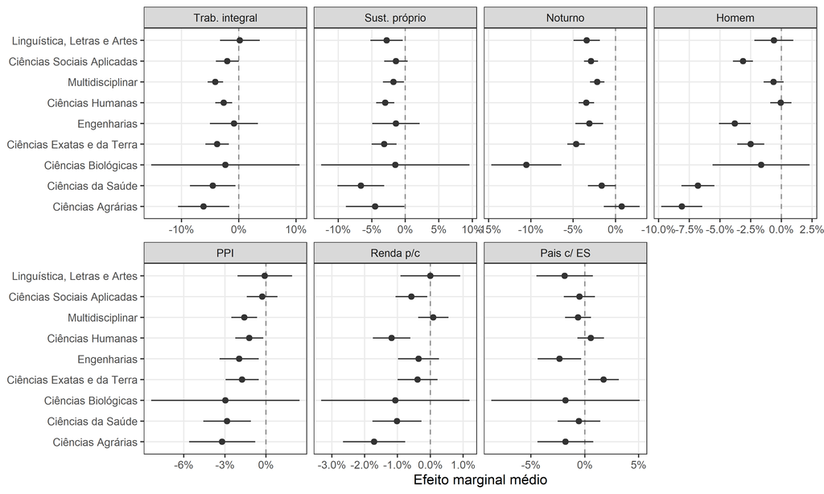

Figura 5: Efeitos marginais médios por área, com intervalos de confiança de 95%

```r
destaques |>
  ggplot2::ggplot(ggplot2::aes(x = stats::reorder(area, ame), y = ame)) +
  ggplot2::geom_hline(yintercept = 0, colour = "grey55", linetype = "dashed") +
  ggplot2::geom_pointrange(ggplot2::aes(ymin = inf, ymax = sup),
                           size = 0.32, colour = "grey20") +
  ggplot2::facet_wrap(~ efeito, ncol = 4, scales = "free_x") +
  ggplot2::scale_y_continuous(labels = scales::percent) +
  ggplot2::coord_flip() +
  ggplot2::labs(x = NULL, y = "Efeito marginal médio") +
  TEMA
```

Fonte: elaboração própria a partir de dados do SIC-USP.

**código**

```r
maiores <- ames_area |>
  dplyr::filter(variavel != "ano", !grepl("^Outros", nivel), p < 0.05) |>
  dplyr::group_by(area) |>
  dplyr::slice_max(abs(ame), n = 1) |>
  dplyr::ungroup()

maiores |>
  dplyr::transmute(`Área` = abreviar_area(area), N = num(n),
                   Fator = paste0(variavel, ": ", nivel),
                   `Efeito (pp)` = sprintf("%+.1f", 100 * ame),
                   `IC 95%` = ic(inf, sup)) |>
  knitr::kable(align = "lrlrr")
```

Tabela 9: O fator de maior efeito em cada área

| Área | N | Fator | Efeito (pp) | IC 95% |
| --- | --- | --- | --- | --- |
| C. da Saúde | 16.061 | sexo: M (vs F) | -6.8 | [-8.14; -5.46] |
| C. Biológicas | 1.631 | periodo: noturno (vs diurno) | -10.5 | [-14.68; -6.41] |
| C. Agrárias | 8.213 | sexo: M (vs F) | -8.1 | [-9.78; -6.44] |
| Engenharias | 13.757 | sexo: M (vs F) | -3.8 | [-5.09; -2.51] |
| C. Humanas | 19.430 | periodo: noturno (vs diurno) | -3.4 | [-4.35; -2.54] |
| C. Exatas e da Terra | 14.256 | periodo: noturno (vs diurno) | -4.7 | [-5.68; -3.63] |
| C. Sociais Aplicadas | 17.791 | sexo: M (vs F) | -3.1 | [-3.94; -2.32] |
| Multidisciplinar | 16.061 | trabalho: Sim, em tempo integral (vs Não) | -4.1 | [-5.46; -2.73] |
| Letras e Artes | 4.130 | periodo: noturno (vs diurno) | -3.4 | [-4.96; -1.85] |

Fonte: elaboração própria a partir de dados do SIC-USP. Considerados apenas efeitos com p < 0,05; excluídos o ano de ingresso e a categoria residual do sustento.

**código**

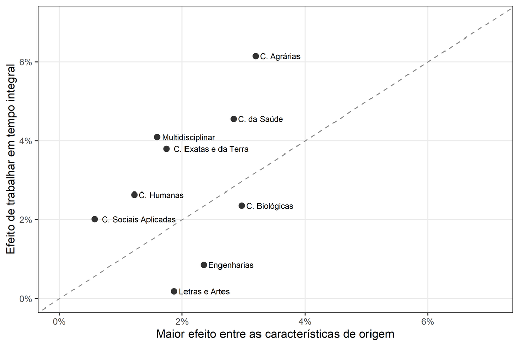

Figura 6: Trabalho contra origem social: acima da diagonal, o trabalho pesa mais

```r
largo <- destaques |>
  dplyr::select(area, efeito, ame) |>
  tidyr::pivot_wider(names_from = efeito, values_from = ame)

conf <- largo |>
  dplyr::mutate(trabalho = abs(`Trab. integral`),
                origem = pmax(abs(PPI), abs(`Renda p/c`), abs(`Pais c/ ES`)))

conf |>
  ggplot2::ggplot(ggplot2::aes(x = origem, y = trabalho, label = abreviar_area(area))) +
  ggplot2::geom_abline(slope = 1, intercept = 0, linetype = "dashed", colour = "grey55") +
  ggplot2::geom_point(size = 2.6, colour = "grey20") +
  ggplot2::geom_text(hjust = -0.1, size = 3) +
  ggplot2::expand_limits(x = c(0, max(conf$origem) * 2.2),
                         y = c(0, max(conf$trabalho) * 1.15)) +
  ggplot2::scale_x_continuous(labels = scales::percent) +
  ggplot2::scale_y_continuous(labels = scales::percent) +
  ggplot2::labs(x = "Maior efeito entre as características de origem",
                y = "Efeito de trabalhar em tempo integral") + TEMA
```

Fonte: elaboração própria a partir de dados do SIC-USP.

A primeira é convergente com o estudo anterior. O efeito de trabalhar em tempo integral supera a maior das características de origem em 6 das 9 áreas, de modo que a hierarquia encontrada na FFLCH não parece ser peculiaridade daquela unidade.

### O efeito de gênero sobrevive ao curso?

O efeito de sexo exige um teste que o desenho por área não fornece. Uma área abriga dezenas de cursos com composições de sexo e taxas de IC bastante distintas: em Ciências da Saúde convivem Enfermagem e Medicina, e em Ciências Agrárias, Veterinária e Zootecnia. Parte do que estamos atribuindo ao sexo pode ser, portanto, composição de curso, isto é, a segregação horizontal descrita por Carvalhaes e Ribeiro (2019), e não um fenômeno que se passe no interior dos cursos.

**código**

```r
FORMULA_CURSO <- stats::update(FORMULA_BASE, . ~ . + curso)

preparar <- function(d) {
  d |> dplyr::select(dplyr::all_of(VARIAVEIS), curso) |>
    stats::na.exclude() |>
    dplyr::group_by(curso) |>
    dplyr::filter(dplyr::n() >= 100, dplyr::n_distinct(IC) > 1) |>
    dplyr::ungroup()
}

sexo_de <- function(m, d) {
  a <- ame(m, d); a[a$nivel == "M (vs F)", c("ame", "inf", "sup", "p")]
}

genero <- do.call(rbind, lapply(areas, function(a) {
  d <- preparar(dplyr::filter(mod, area == a))
  if (nrow(d) < 500 || dplyr::n_distinct(d$curso) < 2) return(NULL)
  s <- sexo_de(ajustar(d, FORMULA_BASE), d)
  c_ <- sexo_de(ajustar(d, FORMULA_CURSO), d)
  data.frame(area = a, n = nrow(d), cursos = dplyr::n_distinct(d$curso),
             ame_sem = s$ame, ame_com = c_$ame, inf = c_$inf, sup = c_$sup,
             p = c_$p)
}))

genero |>
  dplyr::arrange(ame_com) |>
  dplyr::transmute(`Área` = abreviar_area(area), N = num(n),
                   Cursos = cursos,
                   `Sem controle` = sprintf("%+.1f", 100 * ame_sem),
                   `Com controle` = sprintf("%+.1f", 100 * ame_com),
                   `IC 95%` = ic(inf, sup),
                   p = ifelse(p < 0.001, "<0,001", sprintf("%.3f", p))) |>
  knitr::kable(align = "lrrrrrr")
```

Tabela 10: Efeito marginal médio de ser homem, antes e depois do controle por curso

| Área | N | Cursos | Sem controle | Com controle | IC 95% | p |
| --- | --- | --- | --- | --- | --- | --- |
| C. Agrárias | 8.213 | 11 | -8.1 | -5.3 | [-7.07; -3.58] | <0,001 |
| C. da Saúde | 15.873 | 15 | -6.7 | -4.7 | [-6.14; -3.18] | <0,001 |
| Engenharias | 13.643 | 14 | -3.8 | -3.4 | [-4.74; -2.06] | <0,001 |
| C. Sociais Aplicadas | 17.723 | 10 | -3.1 | -1.9 | [-2.68; -1.05] | <0,001 |
| C. Exatas e da Terra | 14.054 | 24 | -2.5 | -1.7 | [-2.79; -0.55] | 0.003 |
| Multidisciplinar | 15.930 | 24 | -0.6 | -1.5 | [-2.38; -0.62] | <0,001 |
| C. Biológicas | 1.631 | 2 | -1.7 | -1.2 | [-5.15; +2.82] | 0.567 |
| C. Humanas | 19.430 | 7 | -0.1 | -0.7 | [-1.58; +0.19] | 0.124 |
| Letras e Artes | 3.906 | 11 | -0.6 | -0.4 | [-1.98; +1.26] | 0.664 |

Fonte: elaboração própria a partir de dados do SIC-USP.

O controle altera as magnitudes sem eliminar o efeito. Em Ciências da Saúde e em Ciências Agrárias, cerca de um terço do efeito de gênero corresponde a composição de curso, e os dois terços restantes permanecem, com intervalos de confiança distantes do zero. Em Engenharias a mudança é pequena. O efeito segue significativo em 6 das 9 áreas, e é nulo justamente em Ciências Humanas — o que reconcilia o resultado com o do estudo anterior, que não encontrou efeito de sexo na FFLCH.

Registramos o padrão sem explicá-lo. Nosso desenho não distingue entre as hipóteses possíveis: diferenças de desempenho acadêmico, de disponibilidade para atividades não remuneradas, de relação com orientadores, ou de custo de oportunidade no mercado de trabalho para essas formações. É uma agenda, não uma conclusão.

## ROBUSTEZ: AS DUAS JANELAS DE COORTE

**código**

```r
estimar_em <- function(janela) {
  d <- dplyr::filter(painel, ano %in% janela)
  md <- amostra_modelo(d, com_area = TRUE)
  m <- ajustar(md, FORMULA_AREA)
  ame(m, md) |>
    dplyr::mutate(chave = paste(variavel, nivel, sep = "|")) |>
    dplyr::filter(chave %in% names(DESTAQUES)) |>
    dplyr::transmute(efeito = unname(DESTAQUES[chave]),
                     v = sprintf("%+.2f %s", 100 * ame, ic(inf, sup)))
}

dplyr::full_join(
  dplyr::rename(estimar_em(COORTES_MODELO), `2010–2022` = v),
  dplyr::rename(estimar_em(COORTES), `2010–2018` = v), by = "efeito") |>
  dplyr::rename(Efeito = efeito) |>
  knitr::kable(align = "lrr")
```

Tabela 11: Efeitos marginais médios nas duas janelas de coorte, em pontos percentuais

| Efeito | 2010–2022 | 2010–2018 |
| --- | --- | --- |
| Homem | -3.13 [-3.52; -2.74] | -3.94 [-4.45; -3.43] |
| PPI | -1.73 [-2.22; -1.25] | -0.98 [-1.64; -0.32] |
| Pais c/ ES | -0.40 [-0.99; +0.19] | -0.22 [-0.98; +0.53] |
| Renda p/c | -0.77 [-1.01; -0.53] | -0.97 [-1.28; -0.65] |
| Trab. integral | -3.73 [-4.59; -2.86] | -3.87 [-4.99; -2.75] |
| Sust. próprio | -3.28 [-4.07; -2.50] | -3.01 [-4.03; -1.99] |
| Noturno | -3.06 [-3.49; -2.64] | -3.46 [-4.01; -2.91] |

Fonte: elaboração própria a partir de dados do SIC-USP.

## CONSIDERAÇÕES FINAIS

O terceiro não estava previsto no desenho. O sexo, cujo efeito na FFLCH não se distinguia de zero, é o maior efeito em quatro áreas, sempre na mesma direção, e permanece após o controle por curso, o que afasta a leitura de que se trate apenas de segregação entre carreiras. Não dispomos de elementos para explicá-lo, e o registramos como questão a ser investigada.

Três limitações pesam sobre essas conclusões. Não há indicador de desempenho acadêmico, e a classificação na carreira no vestibular é um proxy pobre, sobretudo ao comparar áreas cujos processos seletivos têm concorrências muito diferentes. O sub-registro de bolsas fora do CNPq no sistema Atena não é uniforme entre áreas: se as unidades das ciências experimentais registram melhor suas bolsas da FAPESP do que as de humanidades, parte da diferença que atribuímos à área é diferença de registro — e o ranking de áreas é a espinha dorsal do artigo. Não temos como quantificar esse viés com os dados disponíveis, e ele é a primeira coisa que um estudo seguinte deveria enfrentar. A classificação das unidades em áreas é nossa, e ainda que registrada de forma auditável, é uma escolha que outro pesquisador poderia fazer diferente.

## REFERÊNCIAS

BREEN, Richard; JONSSON, Jan O. (2005), “Inequality of Opportunity in Comparative Perspective: Recent Research on Educational Attainment and Social Mobility”. *Annual Review of Sociology*, v. 31, pp. 223-243.

BRITO, Murillo Marschner Alves de. (2017), “Novas tendências ou velhas persistências? Modernização e expansão educacional no Brasil”. *Cadernos de Pesquisa*, v. 47, n. 163, pp. 224-263.

CANAAN, Mariana Gadoni; NOGUEIRA, Maria Alice. (2015), “Bens em disputa no campo universitário: o efeito de fatores socioeconômicos e culturais no acesso à bolsa de iniciação científica”, in: MASSI, Luciana; QUEIROZ, Salete Linhares (orgs.), *Iniciação científica: aspectos históricos, organizacionais e formativos da atividade no ensino superior brasileiro*. São Paulo, Editora UNESP, pp. 61-89.

CARVALHAES, Flavio; RIBEIRO, Carlos Antonio Costa. (2019), “Estratificação horizontal da educação superior no Brasil: desigualdades de classe, gênero e raça em um contexto de expansão educacional”. *Tempo Social*, v. 31, n. 1, pp. 195-233.

COMIN, Alvaro Augusto; BARBOSA, Rogério Jerônimo. (2011), “Trabalhar para estudar: sobre a pertinência da noção de transição escola-trabalho no Brasil”. *Novos Estudos CEBRAP*, v. 91, pp. 75-95.

GERBER, Theodore P.; CHEUNG, Sin Yi. (2008), “Horizontal Stratification in Postsecondary Education: Forms, Explanations, and Implications”. *Annual Review of Sociology*, v. 34, pp. 299-318.

KNOP, Márcia; COLLARES, Ana Cristina Murta. (2019), “A influência da origem social na probabilidade de concluir os diferentes cursos de ensino superior”. *Sociedade e Estado*, v. 34, n. 2, pp. 351-380.

MANÇANO, Tales; ALCANTARA, Victor. (2025), *Quem faz Iniciação Científica? Um estudo sobre as desigualdades socioeconômicas no acesso à Iniciação Científica FFLCH-USP (2010-2022)*. Pacote de replicação. Disponível em: https://github.com/mancano-tales/Quem-faz-IC-na-FFLCH.

MARE, Robert D. (1980), “Social Background and School Continuation Decisions”. *Journal of the American Statistical Association*, v. 75, n. 370, pp. 295-305.

RIBEIRO, Carlos Antonio Costa; CARVALHAES, Flavio. (2020), “Estratificação e mobilidade social no Brasil: uma revisão da literatura na sociologia de 2000 a 2018”. *BIB — Revista Brasileira de Informação Bibliográfica em Ciências Sociais*, pp. 1-46.

SALATA, André. (2018), “Ensino superior no Brasil das últimas décadas: redução nas desigualdades de acesso?”. *Tempo Social*, v. 30, n. 2, pp. 219-253.

SENKEVICS, Adriano Souza; CARVALHAES, Flavio; RIBEIRO, Carlos Antonio Costa. (2022), “Mérito ou berço? Origem social e desempenho no acesso ao ensino superior”. *Cadernos de Pesquisa*, v. 52, e09528.

## APÊNDICE: AMBIENTE COMPUTACIONAL

**código**